# The China Shock data — a guide

Diversity in a Globalized World

Published

September 9, 2026

# What this data is about

In the 1990s and 2000s, China went from making very little for the world market to making a great deal of it. American factories that made the same things — clothes, furniture, toys, electronics — suddenly had a competitor.

But this did not happen evenly across the United States. A town whose factories made furniture felt it strongly. A town that grew wheat barely noticed. Two economists, David Autor and David Dorn, together with Gordon Hanson, measured how hard each part of the country was hit, and then measured what happened to jobs there.

**This folder contains their data, cleaned up so you can work with it directly.**

You are not expected to download anything, clean anything, or join anything together. That is done. You open a file and start looking.

# The two files

There are two files, and they hold the same information in two different shapes. Which one you use depends on whether you are drawing a **map** or a **graph**.

| File | Use it for | What one row is | Rows |
| --- | --- | --- | --- |
| `zones.rds` | **Maps**, and most graphs | One place, one time period | 1,444 |
| `jobs.rds` | Comparing **men and women** | One place, one period, one sex | 2,792 |

`zones.rds` carries 44 variables. `jobs.rds` is a smaller, reshaped slice of the same data, built so that men and women sit in separate rows and can be compared directly.

# How to open them

Put both files in a folder called `preprocessed_data` next to your `.qmd` file, then:

```r
library(sf)
library(ggplot2)

zones <- readRDS("preprocessed_data/zones.rds")
jobs  <- readRDS("preprocessed_data/jobs.rds")
```

That is all. No `read.csv`, no file paths to fight with, no packages to install beyond the ones you used in class.

# First, what is a “zone”?

The data is not organised by city or by state. It is organised by **commuting zone** — a group of towns close enough together that people live in one and work in another.

This is a better unit than a city for our purposes. If the factory in your town closes, you might find work two towns over without moving house. A commuting zone is roughly “the area where you could realistically look for a job.”

The continental United States has **722** of them. Every zone has a number, called `zone_id`.

# `zones.rds` — the main file

Each row is one commuting zone in one time period. Since there are 722 zones and two periods, there are 1,444 rows — **every zone appears twice**.

That matters for maps. If you draw a map without choosing a period, R will try to draw each zone twice on top of itself. So pick a period first:

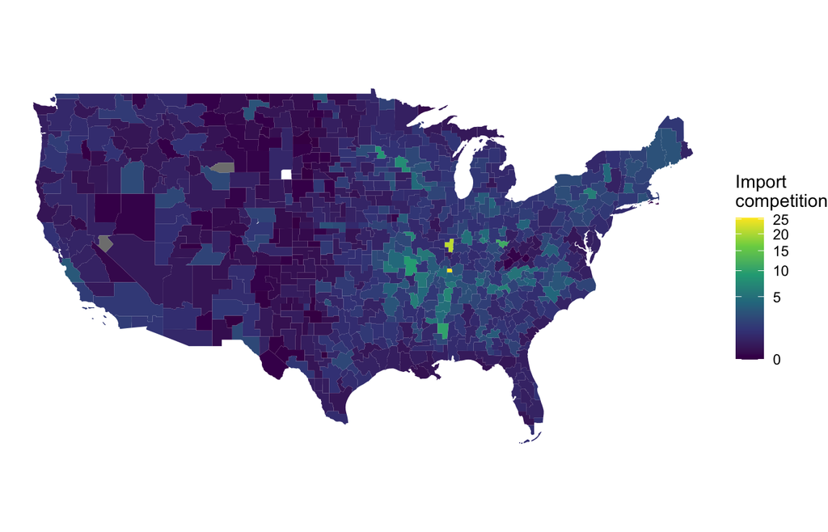

```r
nineties <- zones[zones$period == "1990-2000", ]

ggplot(nineties) +
  geom_sf(aes(fill = import_competition), color = NA) +
  scale_fill_viridis_c(trans = "sqrt", name = "Import\ncompetition") +
  theme_void()
```

Swap `import_competition` for any variable below and you get a different map.

## Where and when

| Variable | What it means |
| --- | --- |
| `zone_id` | The zone’s ID number |
| `state_fips` | State code |
| `region` | Northeast, Midwest, South or West |
| `period` | `1990-2000` or `2000-2007` |
| `geom` | The shape on the map — you never touch this directly |

## How hard China hit

| Variable | What it means |
| --- | --- |
| `import_competition` | Chinese imports arriving in this zone’s industries. Bigger = hit harder |
| `import_competition_other` | The same thing, but measured from China’s exports to *other* rich countries. Economists use this as a cleaner comparison |

## What the zone looked like at the start

All of these are measured at the **beginning** of the period.

| Variable | What it means |
| --- | --- |
| `population` | How many people lived there |
| `manuf_share_start` | % of jobs in factories |
| `college_share` | % of adults with a college degree |
| `foreign_born_share` | % of people born outside the US |
| `female_empl_share` | % of workers who were women |
| `routine_jobs_share` | % of jobs that were repetitive and rule-based |
| `mfg_start` | % of jobs that were factory jobs |
| `mfg_start_women` / `mfg_start_men` | The same, for women only / men only |
| `mfg_start_college` / `mfg_start_nocollege` | The same, by education |
| `unemployed_start` | % of people unemployed |
| `not_in_labour_start` | % of people not looking for work at all |
| `wage_mfg_start` / `wage_nonmfg_start` | Typical weekly pay, in factories / outside them |

## What changed over the period

| Variable | What it means |
| --- | --- |
| `mfg_change` | Change in % of jobs that were factory jobs |
| `mfg_change_women` / `mfg_change_men` | The same, by sex |
| `mfg_change_college` / `mfg_change_nocollege` | The same, by education |
| `nonmfg_change` | Change in **non**-factory employment |
| `nonmfg_change_women` / `nonmfg_change_men` | The same, by sex |
| `unemployed_change` | Change in % unemployed |
| `unemployed_change_women` / `_men` | The same, by sex |
| `not_in_labour_change` | Change in % who stopped looking for work |
| `not_in_labour_change_women` / `_men` | The same, by sex |
| `wage_change` | Change in typical weekly pay |
| `wage_change_women` / `wage_change_men` | The same, by sex |
| `population_change` | Change in population |
| `household_income_change` | Change in average household income per person |

## Government payments

When people lose work, government money often follows. These track it.

| Variable | What it means |
| --- | --- |
| `disability_recipients_change` | Change in % of people on disability benefits |
| `disability_payments_change` | Change in disability money paid per person |
| `unemployment_payments_change` | Change in unemployment money paid per person |
| `trade_adjustment_payments_change` | Change in *Trade Adjustment Assistance* — money paid specifically to workers who lost jobs to imports |

# `jobs.rds` — for comparing men and women

In `zones.rds`, men and women sit in separate *columns*. That is awkward if you want them as two coloured lines on one graph. `jobs.rds` is the same data reshaped so they sit in separate **rows**, with a `sex` column saying which is which.

```r
head(jobs)
```

```
# A tibble: 6 × 12
  zone_id region period    import_competition sex   mfg_start mfg_change
    <dbl> <chr>  <chr>                  <dbl> <chr>     <dbl>      <dbl>
1     100 South  1990-2000               5.29 Women      14.5     -3.89
2     100 South  1990-2000               5.29 Men        26.8     -3.92
3     100 South  2000-2007               6.62 Women      10.6     -4.14
4     100 South  2000-2007               6.62 Men        22.9     -5.03
5     200 South  1990-2000               3.03 Women      13.7     -2.37
6     200 South  1990-2000               3.03 Men        22.3      0.968
# ℹ 5 more variables: nonmfg_change <dbl>, unemployed_change <dbl>,
#   not_in_labour_change <dbl>, wage_change <dbl>,
#   mfg_change_share_of_start <dbl>
```

| Variable | What it means |
| --- | --- |
| `zone_id`, `region`, `period` | Same as in `zones.rds` |
| `sex` | `Men` or `Women` |
| `import_competition` | Same measure as above |
| `mfg_start` | % of the zone’s jobs this group held in factories at the start |
| `mfg_change` | How much that changed, **in percentage points** |
| `mfg_change_share_of_start` | The same change, as **a share of `mfg_start`** |
| `nonmfg_change` | Change in this group’s non-factory employment |
| `unemployed_change` | Change in this group’s unemployment |
| `not_in_labour_change` | Change in this group’s share who stopped looking for work |
| `wage_change` | Change in this group’s typical weekly pay |

**A graph also takes one line:**

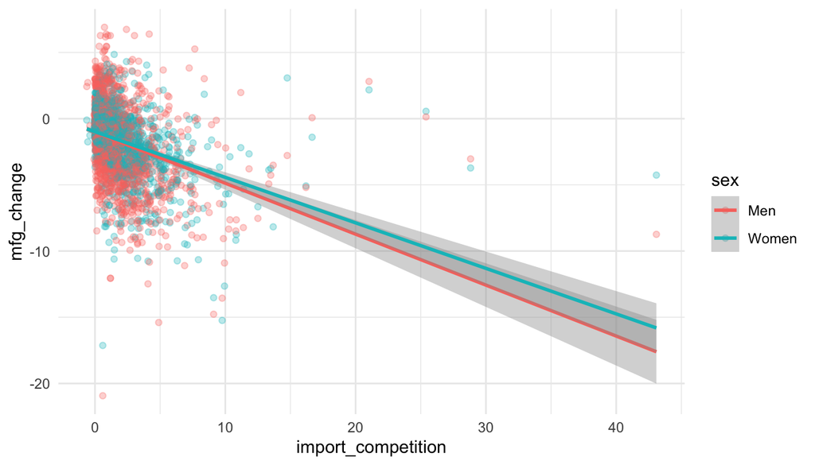

```r
ggplot(jobs, aes(x = import_competition, y = mfg_change, color = sex)) +
  geom_point(alpha = 0.3) +
  geom_smooth(method = "lm") +
  theme_minimal()
```

# The one thing that will confuse you

`mfg_change` and `mfg_change_share_of_start` sound like the same thing. They are not, and the difference matters more than anything else in this data.

Imagine a zone where women held **7%** of the jobs in factories and men held **15%**. Both groups then lose **3 percentage points**.

- In `mfg_change`, both lose the same: **−3** each.
- In `mfg_change_share_of_start`, women lost 3 out of 7, which is **−43%**. Men lost 3 out of 15, which is **−20%**.

Same event, two numbers, two impressions. `mfg_change` tells you how much the local job market shifted. `mfg_change_share_of_start` tells you how much of that group’s own work disappeared.

Neither is wrong. But **your conclusion can flip depending on which one you use**, so say which one you chose and why.

# Things worth knowing

**`import_competition` is very lopsided.** Most zones have small values and a few have very large ones. On a plain map almost everything comes out the same colour. If that happens, add `trans = "sqrt"` inside `scale_fill_viridis_c()`.

**Bigger `import_competition` means hit harder**, and most `change` values are negative because factory jobs were disappearing everywhere. So a downward-sloping line means “more competition went with bigger losses.”

**We removed a few zones** where almost nobody worked in factories to begin with. Dividing by a tiny starting number produced percentages in the hundreds, which are technically correct and practically meaningless.

**Every zone appears twice in `zones.rds`** — once per period. Filter to one period before mapping, or the two will be drawn on top of each other.

**`wage_change` is a log change**, so roughly: 0.05 means about 5% higher pay.

# Questions you could ask

These are starting points, not a list to work through.

- Which regions were hit hardest, and does that match where factory work was?
- When factory jobs disappeared, did non-factory jobs replace them (`nonmfg_change`), or did people stop looking for work (`not_in_labour_change`)?
- Did places hit harder end up with more people on disability benefits (`disability_recipients_change`)? That is a well-known and contested claim.
- Did `trade_adjustment_payments_change` actually rise where imports hit hardest — did the money meant for these workers reach them?
- Were places with more immigrants (`foreign_born_share`) hit more or less?
- Did zones with more `routine_jobs_share` suffer more?
- Did college and non-college workers fare differently (`mfg_change_college` vs `mfg_change_nocollege`)?
- Do men and women show the same pattern, and does your answer depend on which of the two change measures you use?

# Where the data comes from

Autor, D. H., Dorn, D., & Hanson, G. H. (2013). The China Syndrome: Local Labor Market Effects of Import Competition in the United States. *American Economic Review*, 103(6), 2121–2168.

The replication files are public, on David Dorn’s website. Map boundaries come from the US Census Bureau. We joined them together, renamed the variables into plain English, and rounded the numbers.